# act_report

**WeRateDogs** is a popular twitter account created by a college student Matt Nelson in the year 2015 [11].The Twitter account rates people's dogs with a humorous comment about the dog. These ratings almost always have a denominator of 10. However,the numerators are always greater than 10. 11/10, 12/10, 13/10, etc. are some of the typical score. But, Why? Because "they're good dogs Brent." WeRateDogs has over 4 million followers and has received international media coverage. To analyze the data of WeRateDogs data has been gathered from the following three sources:

1. The WeRateDogs Twitter archive: twitter_archive_enhanced.csv has been received from the Udacity instructor and downloded.
2. A file (image_predictions.tsv) is hosted on Udacity's servers and has been downloaded programmatically using the Requests library and the specified URL: https://d17h27t6h515a5.cloudfront.net/topher/2017/August/599fd2ad_image-predictions/image-predictions.tsv.
1. Using the tweet IDs in the WeRateDogs Twitter archive, query have been made of the Twitter API for each tweet's JSON data using Python's Tweepy library and entire set of JSON data has been stored in a file called tweet_json.txt file.

After gathering the data has been cleaned as we have identified 9 quality issues and 02 tidyness issues. After that the following relationship has been explored:

1. Most frequent dog genres predicted by the algorithm
1. Most freuqunet dog stages
1. Time- Year, Month and hour of tweeting
1. Popular dog names
1. Correlation coeffiecnt

## 1. Most frequent dog genres predicted by the algorithm

**From Figure-1, 2 and 3 following observations can be made.**

**A.** Golden retriever is the most common dog genre predicted by the algorithm in the first instance.

**B.** Labrador retriever is considered as the second most common category by the algorithm.

**C.** Most popular categories are common in prediction 1, 2 and 3 with different frequency.

[figure not shown]

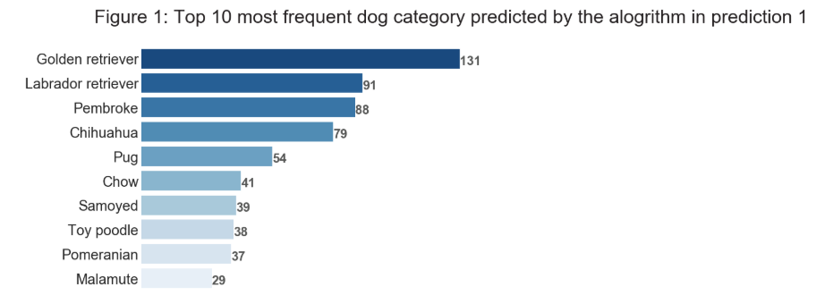

```python
from IPython.display import display
from PIL import Image
path="C:\\Users\\raz37388\\Desktop\\udacity-git-course\\new-git-project\\Data Story\\Communicate_Data_Findings\\most_freq_1.png"
display(Image.open(path))
```

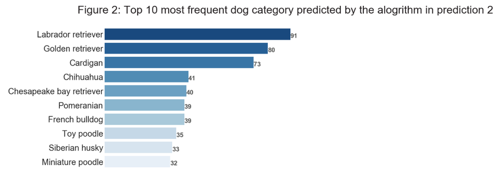

```python
from IPython.display import Image
Image(filename='Figure_2.png')
```

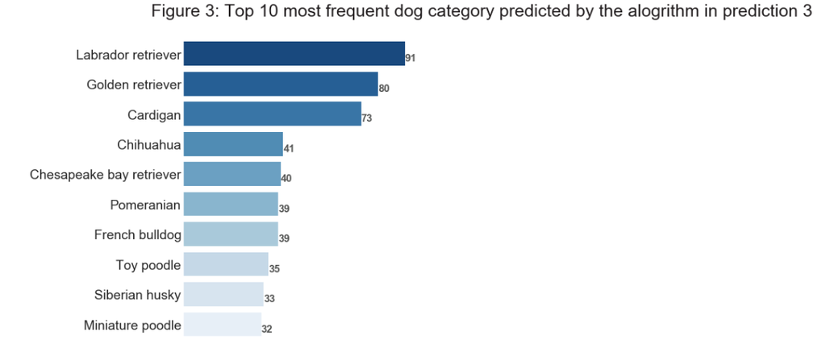

```python
from IPython.display import Image
Image(filename='Figure_3.png')
```

### 2. Most frequent dog stages

**For most of the tweet the stage information is not available. Here we have just focused on the tweets with an available stage name.:**

**1.** Pupper is the most frequent stage.

**2.** Floofer is the least frequent stage.

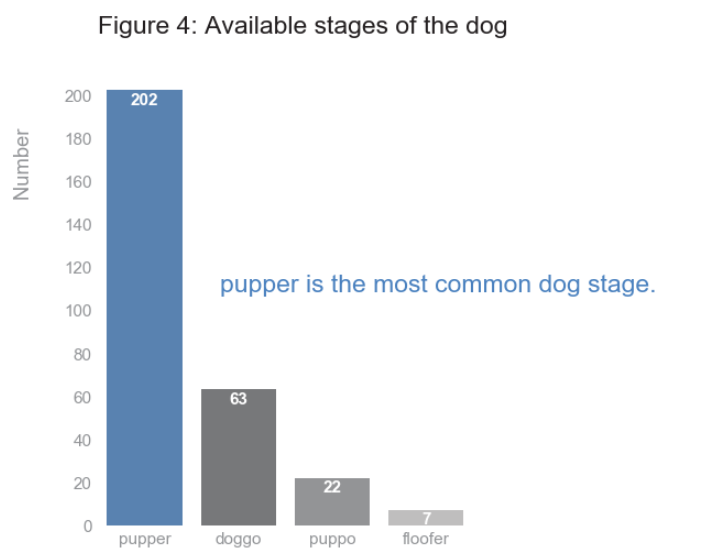

```python
from IPython.display import Image
Image(filename='Figure_4.png')
```

### 3. Time- Year, Month and hour of tweet

**1.** Most of the tweets are from the year 2016 (See Figure 5) .

**2.** 41% tweets were done between Jan-Mar in 2016 ((See Figure 6)

**3.** There is an increase in number during June and July after a brief quiet period in April and May ((See Figure 6).

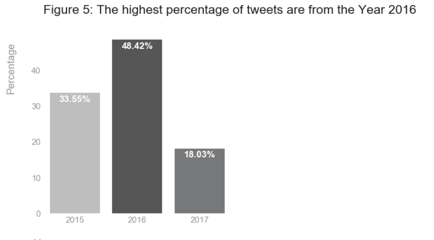

```python
from IPython.display import Image
Image(filename='Figure_5.png')
```

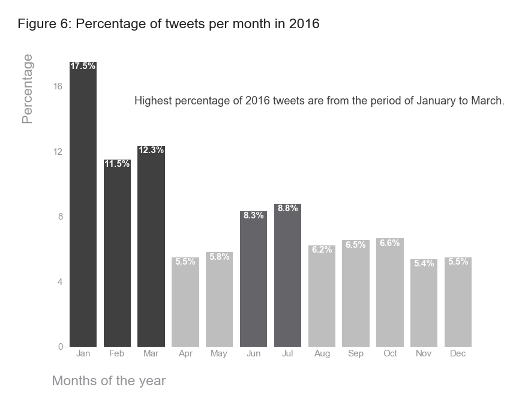

```python
from IPython.display import Image
Image(filename='Figure_6.png', width = 800, height = 1200)
```

**1.** Apparently, people prefer to do tweets during the night.

**2.** 0-2 hours is the busiest period of the day while 6-14 is the quietest period.

**3.** Users start to be active again gradually from the 14 hours onward.

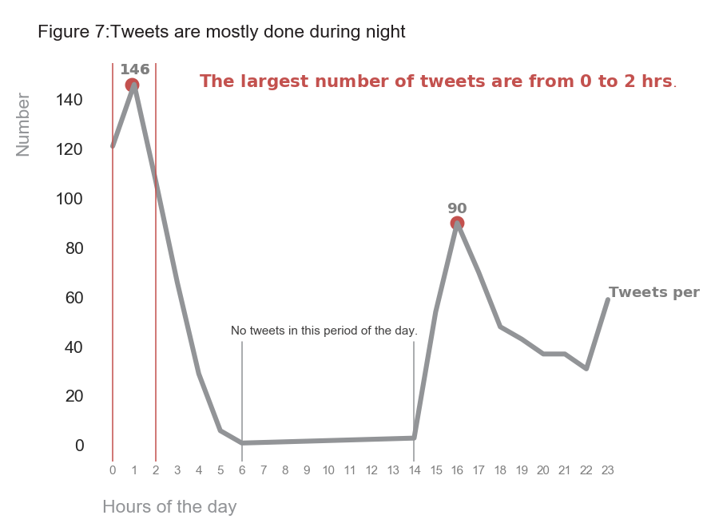

```python
from IPython.display import Image
Image(filename='Figure_7.png')
```

### 4. Popular dog names

**1.** There is a big number of tweets with missing and erroneous names.

**2.** Charlie, Cooper, Oliver and Lucy are the most popular dog names as can be seen below.

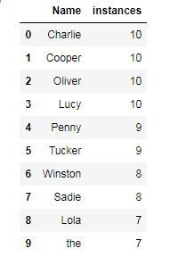

```python
from IPython.display import Image
Image(filename='Figure_Names.png')
```

### 5. Correlation Coefficient

**1.** From the correlation table- we can observe several moderate and strong correlation factors between variables.

**2.** The strongest meaningful correlation is observed between favorite_count and retweet_count. (See Figure-8)

**3.** Also, there is a strong negative correlation between p_1 confidence and p_3 confidence.

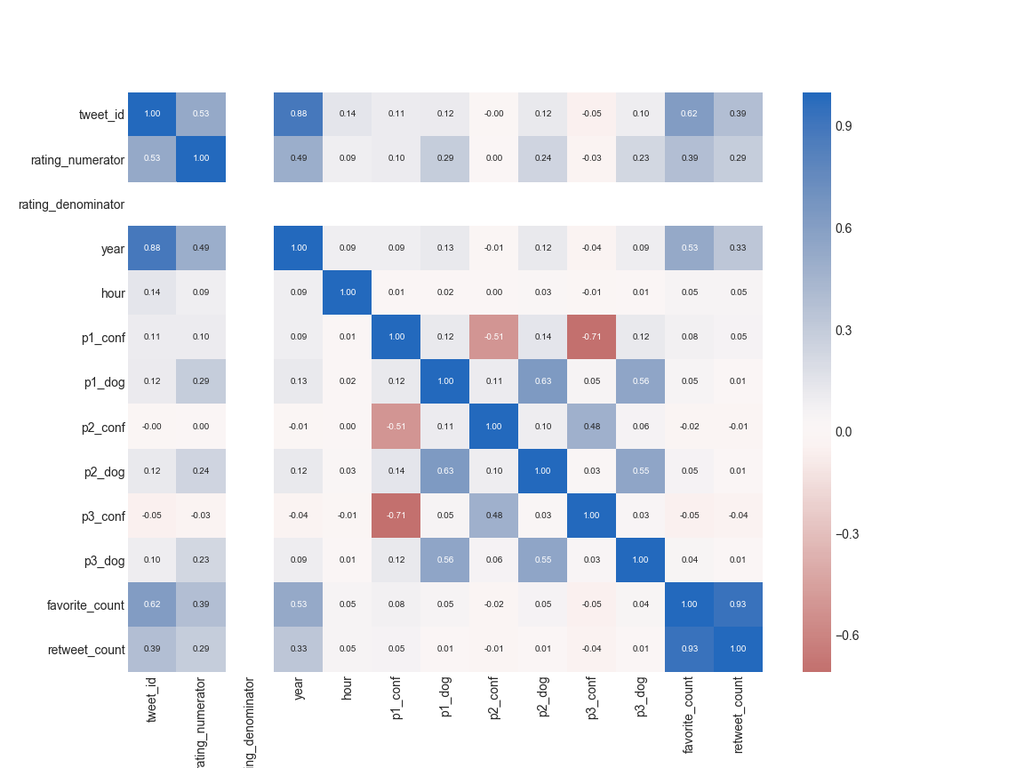

```python
from IPython.display import Image
Image(filename='Figure_8.png')
```

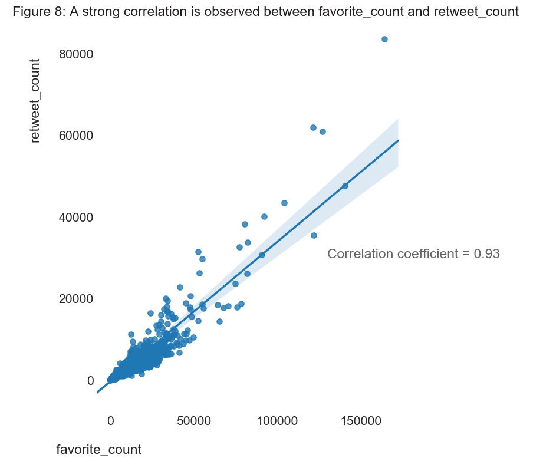

```python
from IPython.display import Image
Image(filename='Figure_9.png')
```

## Ref:

1. Wiki page WeRateDogs accessed on the 28 Jan, 2019: https://en.wikipedia.org/wiki/WeRateDogs